# Homework 5

Sagar Jain

March 2, 2020

### Exercise 1

Downloaded the dataset.

```r
fed_rd <- readr::read_csv("https://raw.githubusercontent.com/rfordatascience/tidytuesday/master/data/2019/2019-02-12/fed_r_d_spending.csv")
```

#### Part a)

##### *Question:*

Reformat this data with a separate variable called rd_budget_frac for the rd_budget as a fraction of total_outlays and two additional variables with upper and lower confidence bounds for rd_budget_frac from the linear model: **rd_budget_frac ~ department + year**

##### *Answer:*

At First, I created the variable **rd_budget_frac**.  
Then, I did the linear model, and after that, I calculate the confidence intervals.  
Finally, I left join them with the original dataset.

```r
fed_rd.new <- fed_rd %>%
  mutate(rd_budget_frac = rd_budget/total_outlays)
fit <- lm(rd_budget_frac ~ department + year, fed_rd.new)
conf.int <- augment(fit) %>%
  mutate(fit = .fitted) %>%
  mutate(upper = .fitted + 1.96 * .se.fit) %>%
  mutate(lower = .fitted + 1.96 * .se.fit) %>%
  select(rd_budget_frac, department, year, fit, upper, lower)
fed_rd.new <- fed_rd.new %>%
  left_join(.,conf.int)

head(fed_rd.new)
```

```
## # A tibble: 6 x 10
##   department  year rd_budget total_outlays discretionary_o~     gdp
##   <chr>      <int>     <dbl>         <dbl>            <dbl>   <dbl>
## 1 DOD         1976   3.57e10  371800000000     175600000000 1.79e12
## 2 NASA        1976   1.25e10  371800000000     175600000000 1.79e12
## 3 DOE         1976   1.09e10  371800000000     175600000000 1.79e12
## 4 HHS         1976   9.23e 9  371800000000     175600000000 1.79e12
## 5 NIH         1976   8.02e 9  371800000000     175600000000 1.79e12
## 6 NSF         1976   2.37e 9  371800000000     175600000000 1.79e12
## # ... with 4 more variables: rd_budget_frac <dbl>, fit <dbl>, upper <dbl>,
## #   lower <dbl>
```

#### Part b)

##### *Question:*

Create four plots showing rd_budget_frac (along with the upper and lower confidence bounds from (a)) as a function of year for NASA, NSF, DHS, and DOD. (Be sure your figure looks polished.) Comment on any patterns you find.

##### *Answer:*

I created a function to plot all 4 plots, since it would be repeating lines of codes. Then, I just called the function foreach department.

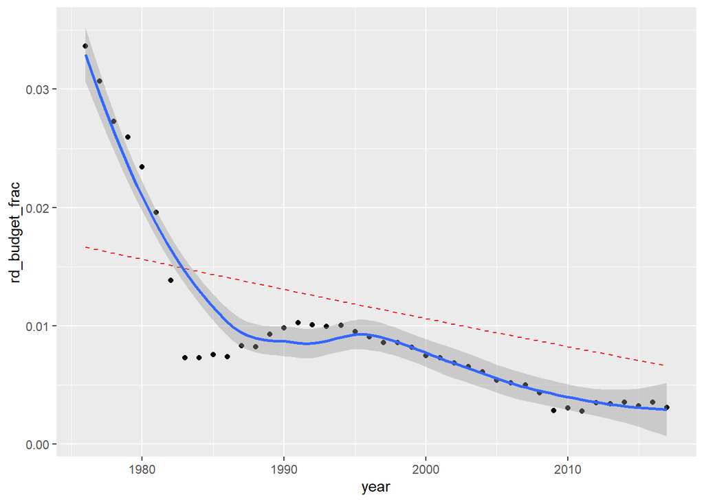

```r
ploting <- function(department){

  coefs.plot=fed_rd.new[which(fed_rd.new$department==department),]

  ggplot(coefs.plot, aes(year, rd_budget_frac))+
    geom_point()+
    geom_line(aes(y=lower), color = "red", linetype = "dashed")+
    geom_line(aes(y=upper), color = "red", linetype = "dashed")+
    geom_smooth()
}
ploting("NASA")
```

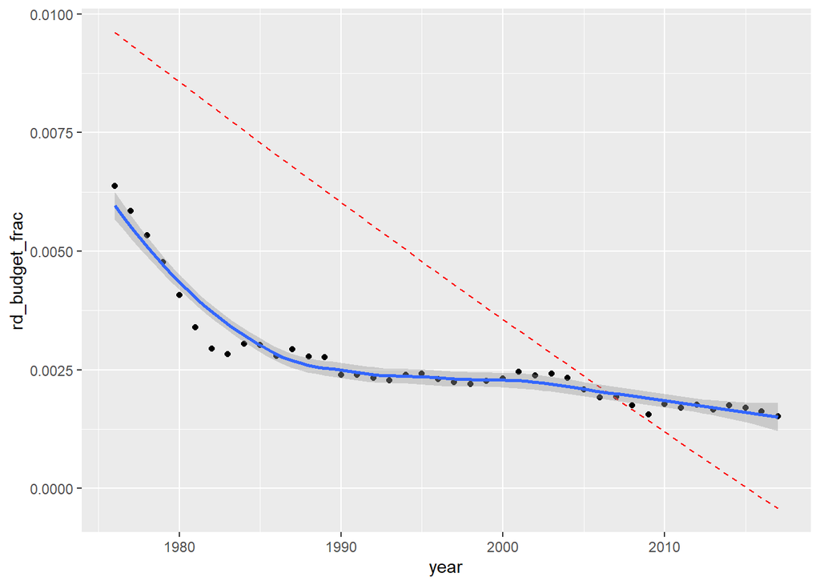

```r
ploting("NSF")
```

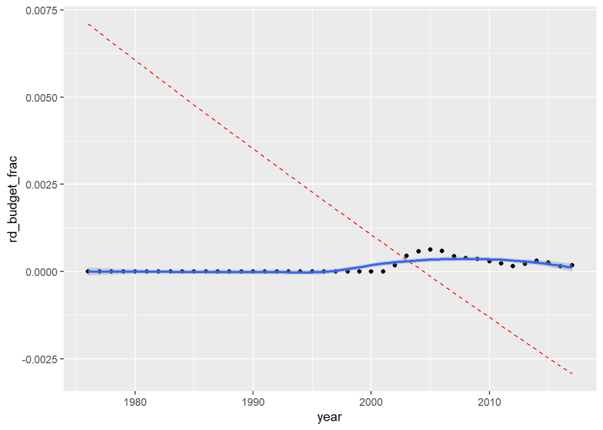

```r
ploting("DHS")
```

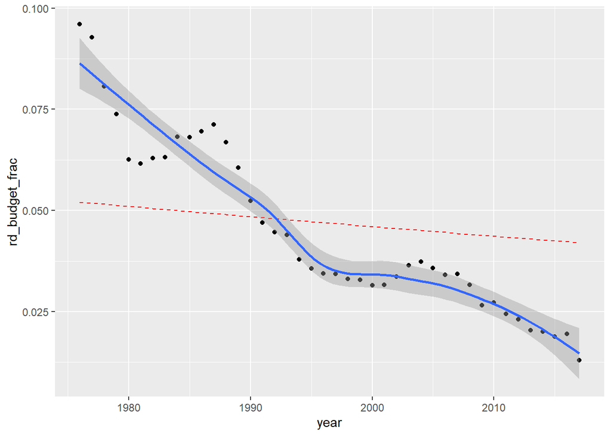

```r
ploting("DOD")
```

*Comments:* Except for *DHS*, the rest have a *descending relation* through the years, *DHS* is a *flat horizontal line until 2001*, approximately.

### Exercise 3

Table 16 of the file UN MigrantStockByOriginAndDestination 2015.xlsx (in the Week 5 Canvas folder) shows migration from one country to another in 2015. By eliminating the rows and columns that don’t correspond to countries and then converting to a tidy dataset using gather() (i.e., a data frame with three columns: one for country of origin, one for country of destination, and the third indicating the number of people who immigrated from one country to the other), find

First, I upload the file and clean the dataset.

```r
getwd()
```

```
## [1] "C:/Users/sagar/OneDrive/Documents"
```

```r
untidy_migrant <- readxl::read_excel("UN_MigrantStockByOriginAndDestination_2015.xlsx", sheet = "Table 16", skip = 15)
head(untidy_migrant)
```

```
## # A tibble: 6 x 240
##    ...1 ...2  ...3   ...4 ...5   Total `Other North` `Other South`
##   <dbl> <chr> <chr> <dbl> <chr>  <dbl>         <dbl>         <dbl>
## 1     1 WORLD <NA>    900 <NA>  2.44e8       2139539       7644005
## 2     2 Deve~ (b)     901 <NA>  1.40e8        539780       3520214
## 3     3 Deve~ (c)     902 <NA>  1.03e8       1599759       4123791
## 4     4 Leas~ (d)     941 <NA>  1.20e7        241805       1005567
## 5     5 Less~ <NA>    934 <NA>  9.13e7       1357954       3118224
## 6     6 Sub-~ (e)     947 <NA>  1.90e7        328171       1551645
## # ... with 232 more variables: Afghanistan <dbl>, Albania <dbl>,
## #   Algeria <dbl>, `American Samoa` <dbl>, Andorra <dbl>, Angola <dbl>,
## #   Anguilla <dbl>, `Antigua and Barbuda` <dbl>, Argentina <dbl>,
## #   Armenia <dbl>, Aruba <dbl>, Australia <dbl>, Austria <dbl>,
## #   Azerbaijan <dbl>, Bahamas <dbl>, Bahrain <dbl>, Bangladesh <dbl>,
## #   Barbados <dbl>, Belarus <dbl>, Belgium <dbl>, Belize <dbl>,
## #   Benin <dbl>, Bermuda <dbl>, Bhutan <dbl>, `Bolivia (Plurinational
## #   State of)` <dbl>, `Bonaire, Sint Eustatius and Saba` <dbl>, `Bosnia
## #   and Herzegovina` <dbl>, Botswana <dbl>, Brazil <dbl>, `British Virgin
## #   Islands` <dbl>, `Brunei Darussalam` <dbl>, Bulgaria <dbl>, `Burkina
## #   Faso` <dbl>, Burundi <dbl>, `Cabo Verde` <dbl>, Cambodia <dbl>,
## #   Cameroon <dbl>, Canada <dbl>, `Cayman Islands` <dbl>, `Central African
## #   Republic` <dbl>, Chad <dbl>, `Channel Islands` <dbl>, Chile <dbl>,
## #   China <dbl>, `China, Hong Kong Special Administrative Region` <dbl>,
## #   `China, Macao Special Administrative Region` <dbl>, Colombia <dbl>,
## #   Comoros <dbl>, Congo <dbl>, `Cook Islands` <dbl>, `Costa Rica` <dbl>,
## #   `Côte d'Ivoire` <dbl>, Croatia <dbl>, Cuba <dbl>, Curaçao <dbl>,
## #   Cyprus <dbl>, `Czech Republic` <dbl>, `Democratic People's Republic of
## #   Korea` <dbl>, `Democratic Republic of the Congo` <dbl>, Denmark <dbl>,
## #   Djibouti <dbl>, Dominica <dbl>, `Dominican Republic` <dbl>,
## #   Ecuador <dbl>, Egypt <dbl>, `El Salvador` <dbl>, `Equatorial
## #   Guinea` <dbl>, Eritrea <dbl>, Estonia <dbl>, Ethiopia <dbl>, `Faeroe
## #   Islands` <dbl>, `Falkland Islands (Malvinas)` <dbl>, Fiji <dbl>,
## #   Finland <dbl>, France <dbl>, `French Guiana` <dbl>, `French
## #   Polynesia` <dbl>, Gabon <dbl>, Gambia <dbl>, Georgia <dbl>,
## #   Germany <dbl>, Ghana <dbl>, Gibraltar <dbl>, Greece <dbl>,
## #   Greenland <dbl>, Grenada <dbl>, Guadeloupe <dbl>, Guam <dbl>,
## #   Guatemala <dbl>, Guinea <dbl>, `Guinea-Bissau` <dbl>, Guyana <dbl>,
## #   Haiti <dbl>, `Holy See` <dbl>, Honduras <dbl>, Hungary <dbl>,
## #   Iceland <dbl>, India <dbl>, Indonesia <dbl>, `Iran (Islamic Republic
## #   of)` <dbl>, ...
```

```r
untidy_migrant <- untidy_migrant %>%
  rename(to_country = ...2)

untidy_migrant <- untidy_migrant %>%
  rename(country_code = ...4)

untidy_migrant <- filter(untidy_migrant,country_code < 900)
head(untidy_migrant)
```

```
## # A tibble: 6 x 240
##    ...1 to_country ...3  country_code ...5   Total `Other North`
##   <dbl> <chr>      <chr>        <dbl> <chr>  <dbl>         <dbl>
## 1     9 Burundi    <NA>           108 B R   2.87e5          3242
## 2    10 Comoros    <NA>           174 B     1.26e4           597
## 3    11 Djibouti   <NA>           262 B R   1.12e5          1679
## 4    12 Eritrea    <NA>           232 I     1.59e4           693
## 5    13 Ethiopia   <NA>           231 B R   1.07e6         17477
## 6    14 Kenya      <NA>           404 B R   1.08e6         21112
## # ... with 233 more variables: `Other South` <dbl>, Afghanistan <dbl>,
## #   Albania <dbl>, Algeria <dbl>, `American Samoa` <dbl>, Andorra <dbl>,
## #   Angola <dbl>, Anguilla <dbl>, `Antigua and Barbuda` <dbl>,
## #   Argentina <dbl>, Armenia <dbl>, Aruba <dbl>, Australia <dbl>,
## #   Austria <dbl>, Azerbaijan <dbl>, Bahamas <dbl>, Bahrain <dbl>,
## #   Bangladesh <dbl>, Barbados <dbl>, Belarus <dbl>, Belgium <dbl>,
## #   Belize <dbl>, Benin <dbl>, Bermuda <dbl>, Bhutan <dbl>, `Bolivia
## #   (Plurinational State of)` <dbl>, `Bonaire, Sint Eustatius and
## #   Saba` <dbl>, `Bosnia and Herzegovina` <dbl>, Botswana <dbl>,
## #   Brazil <dbl>, `British Virgin Islands` <dbl>, `Brunei
## #   Darussalam` <dbl>, Bulgaria <dbl>, `Burkina Faso` <dbl>,
## #   Burundi <dbl>, `Cabo Verde` <dbl>, Cambodia <dbl>, Cameroon <dbl>,
## #   Canada <dbl>, `Cayman Islands` <dbl>, `Central African
## #   Republic` <dbl>, Chad <dbl>, `Channel Islands` <dbl>, Chile <dbl>,
## #   China <dbl>, `China, Hong Kong Special Administrative Region` <dbl>,
## #   `China, Macao Special Administrative Region` <dbl>, Colombia <dbl>,
## #   Comoros <dbl>, Congo <dbl>, `Cook Islands` <dbl>, `Costa Rica` <dbl>,
## #   `Côte d'Ivoire` <dbl>, Croatia <dbl>, Cuba <dbl>, Curaçao <dbl>,
## #   Cyprus <dbl>, `Czech Republic` <dbl>, `Democratic People's Republic of
## #   Korea` <dbl>, `Democratic Republic of the Congo` <dbl>, Denmark <dbl>,
## #   Djibouti <dbl>, Dominica <dbl>, `Dominican Republic` <dbl>,
## #   Ecuador <dbl>, Egypt <dbl>, `El Salvador` <dbl>, `Equatorial
## #   Guinea` <dbl>, Eritrea <dbl>, Estonia <dbl>, Ethiopia <dbl>, `Faeroe
## #   Islands` <dbl>, `Falkland Islands (Malvinas)` <dbl>, Fiji <dbl>,
## #   Finland <dbl>, France <dbl>, `French Guiana` <dbl>, `French
## #   Polynesia` <dbl>, Gabon <dbl>, Gambia <dbl>, Georgia <dbl>,
## #   Germany <dbl>, Ghana <dbl>, Gibraltar <dbl>, Greece <dbl>,
## #   Greenland <dbl>, Grenada <dbl>, Guadeloupe <dbl>, Guam <dbl>,
## #   Guatemala <dbl>, Guinea <dbl>, `Guinea-Bissau` <dbl>, Guyana <dbl>,
## #   Haiti <dbl>, `Holy See` <dbl>, Honduras <dbl>, Hungary <dbl>,
## #   Iceland <dbl>, India <dbl>, Indonesia <dbl>, ...
```

#### Part a)

##### *Question:*

The top five countries from which people migrate to Canada.

##### *Answer:*

After cleaning the dataset, is easy to use *gather()* to get the answer to this question.

```r
migrate_to_canada <- untidy_migrant[which(untidy_migrant$to_country == "Canada"),]
migrate_to_canada <- migrate_to_canada %>% gather(`Afghanistan`:`Zimbabwe`, key = "from_country", value = "count")

migrate_to_canada_cleaned <- select(migrate_to_canada,c(to_country,
                           from_country,count))

migrate_to_canada_cleaned %>%
  arrange(desc(count)) %>%
  head(5)
```

```
## # A tibble: 5 x 3
##   to_country from_country                                          count
##   <chr>      <chr>                                                 <dbl>
## 1 Canada     China                                                711220
## 2 Canada     India                                                621469
## 3 Canada     United Kingdom of Great Britain and Northern Ireland 607377
## 4 Canada     Philippines                                          545321
## 5 Canada     United States of America                             343252
```

#### Part b)

##### *Question:*

The top five countries to which people migrate from Canada.

##### *Answer:*

```r
migrate_from_canada <- untidy_migrant %>%filter(country_code < 900)
head(arrange(migrate_from_canada, desc(Canada)), n = 5)$to_country
```

```
## [1] "United States of America"
## [2] "United Kingdom of Great Britain and Northern Ireland"
## [3] "Australia"
## [4] "France"
## [5] "Italy"
```

#### Part c)

##### *Question:*

The top 10 migration pairs of countries.

##### *Answer:*

First, I keep only the countries and exclude regions.  
Then, I just looked for the top 10 pairs.

```r
migration_pairs <- untidy_migrant %>%
  gather(`Afghanistan`:`Zimbabwe`, key = "from_country", value = "count") %>% arrange(desc(count))
#Excluding the unnecessary columns
drop_columns <- c("Total","Other North", "Other South", "Country_code", "..1", "..3", "..5")
pairs_top_10 <- migration_pairs[ , !(names(migration_pairs) %in% drop_columns)]
pairs_top_10 %>%
  select(to_country, from_country) %>%
  head(10)
```

```
## # A tibble: 10 x 2
##    to_country                                     from_country
##    <chr>                                          <chr>
##  1 United States of America                       Mexico
##  2 United Arab Emirates                           India
##  3 Ukraine                                        Russian Federation
##  4 Russian Federation                             Ukraine
##  5 India                                          Bangladesh
##  6 Russian Federation                             Kazakhstan
##  7 Kazakhstan                                     Russian Federation
##  8 Iran (Islamic Republic of)                     Afghanistan
##  9 China, Hong Kong Special Administrative Region China
## 10 Jordan                                         State of Palestine
```